# 1st project of Mathematical-Computational Modeling (7600059)

## Professor: Luciano da Fontoura Costa

### Name: Victor Foscarini Almeida

### nUSP:10728101

```python
#libraries
import pandas as pd
import matplotlib.pyplot as plt
import matplotlib.patches as mpatches
import numpy as np
import seaborn as sns
from mpl_toolkits.mplot3d import axes3d
from IPython.display import display, HTML

#colors
PURPLE = '\033[95m'
CYAN = '\033[96m'
DARKCYAN = '\033[36m'
BLUE = '\033[94m'
GREEN = '\033[92m'
YELLOW = '\033[93m'
RED = '\033[91m'
BOLD = '\033[1m'
UNDERLINE = '\033[4m'
END = '\033[0m'
```

# Regression from least squares

## General Regression

- A matrix A containing one column with ones and following columns containing x values is used.
- Then, y is multiplied by A's pseudo-inverse to obtain p, that contains the parameters.

### $\vec{p} = [(A^TA)^{-1}A^T]\;\vec{y}$

### Linear Regression (n points)

$ \vec{y} = \begin{bmatrix}\ y_1 \\ ... \\ y_{n} \end{bmatrix}\; \ A = \begin{bmatrix}\ 1 & x_0\\... & ...\\1 & x_n\end{bmatrix}\; \vec{p} = \begin{bmatrix}\ c \\ m \end{bmatrix} $

### Polinomial Regression (n points, degree k)

$\vec{y} = \begin{bmatrix}\ y_1 \\ ... \\ y_{n} \end{bmatrix}\;$ $\ A = \begin{bmatrix}\ 1 & x_1 & ... & x_1^k \\... & ... & ... & ... \\1 & x_n & ... & x_n^k \end{bmatrix}\;$ $\vec{p} = \begin{bmatrix}\ a_0 \\a_1 \\ ... \\ a_k \end{bmatrix}$

### Regressão Superficial (n points, degrees kx e ky)

$\vec{y} = \begin{bmatrix}\ z_1 \\ ... \\ z_{n} \end{bmatrix}\;$ $\ A = \begin{bmatrix}\ 1 & x_1 & ... & x_1^{kx} & y_1 & ... & y_1^{ky} \\... & ... & ... & ... & ... & ... & ... \\ 1 & x_n & ... & x_n^{kx} & y_n & ... & y_n^{ky} \end{bmatrix}\;$ $\vec{p} = \begin{bmatrix}\ a_0 \\a_1 \\ ... \\ a_{kx} \\ a_{kx+1} \\ ... \\ a_{kx+ky} \end{bmatrix}$

```python
def linear_regression(x,y):
    A = np.column_stack((np.ones(x.shape[0]),x))
    p = np.matmul(np.linalg.pinv(A),y)
    return p
def polynomial_regression(x,y,kx):
    A = np.column_stack((np.ones(x.shape[0]),*[x**i for i in range(1,kx+1)]))
    p = np.matmul(np.linalg.pinv(A),y)
    return p
def superficial_regression(x,y,z,kx,ky):
    A = np.column_stack((np.ones(x.shape[0]),*[x**i for i in range(1,kx+1)],*[y**i for i in range(1,ky+1)]))
    p = np.matmul(np.linalg.pinv(A),z)
    return p
```

## (A) Choose 3 sets of real data with the following characteristics: (i) table X x Y suggesting linear relationship; (ii) table X x Y suggesting a non-linear relationship between these two variables; (iii) table X, Y, Z, with Z = f (X, Y). These data can be from laboratory or internet audiences (eg IBGE, sports, economics, etc.).

- I used a large data set that contains several columns and from there I found the three relationships requested when relating different columns. It is the same data set, but as it is large and contains several columns, I separated it into three other data sets derived from the first for each relationship.

#### (iii) Year x Month x Number

# Reading the file

```python
#reading
data = pd.read_csv('forest_fires_brazil.csv',encoding='latin1')

#grouping data by year, state, month
data = data.groupby(by = ['year','state','month']).sum().reset_index()
data
```

|  | year | state | month | number |
| --- | --- | --- | --- | --- |
| 0 | 1998 | Acre | Abril | 0.000 |
| 1 | 1998 | Acre | Agosto | 130.000 |
| 2 | 1998 | Acre | Dezembro | 7.000 |
| 3 | 1998 | Acre | Fevereiro | 0.000 |
| 4 | 1998 | Acre | Janeiro | 0.000 |
| ... | ... | ... | ... | ... |
| 5492 | 2017 | Tocantins | Maio | 576.000 |
| 5493 | 2017 | Tocantins | Março | 98.000 |
| 5494 | 2017 | Tocantins | Novembro | 434.000 |
| 5495 | 2017 | Tocantins | Outubro | 2.969 |
| 5496 | 2017 | Tocantins | Setembro | 10.737 |

5497 rows × 4 columns

## (B) Apply the least squares method to each of the 3 data sets and show the respective results graphically as curves or surfaces, including the points corresponding to the original data and the respective adjustments. Also show the parameters obtained in the adjustment as a legend in the graphs.

# Linear Regression

## -Parameters: in the upper left corner of the graph

- View the graph in the form of number of fires per year to see the relationship
- Do the regression using the least squares method

```python
#data grouped by years
year_data = data.groupby(by = ['year']).sum().reset_index()
year_data
```

|  | year | number |
| --- | --- | --- |
| 0 | 1998 | 20013.971 |
| 1 | 1999 | 26882.821 |
| 2 | 2000 | 27351.251 |
| 3 | 2001 | 29071.612 |
| 4 | 2002 | 37390.600 |
| 5 | 2003 | 42760.674 |
| 6 | 2004 | 38453.163 |
| 7 | 2005 | 35004.965 |
| 8 | 2006 | 33832.161 |
| 9 | 2007 | 33037.413 |
| 10 | 2008 | 29378.964 |
| 11 | 2009 | 39117.178 |
| 12 | 2010 | 37037.449 |
| 13 | 2011 | 34633.545 |
| 14 | 2012 | 40084.860 |
| 15 | 2013 | 35146.118 |
| 16 | 2014 | 39621.183 |
| 17 | 2015 | 41208.292 |
| 18 | 2016 | 42212.229 |
| 19 | 2017 | 36685.624 |

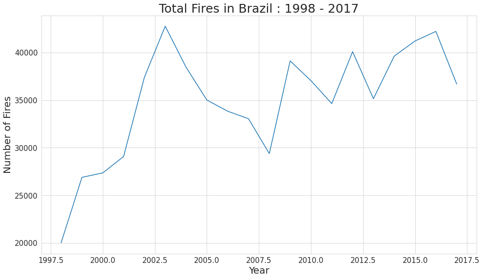

```python
#visualize graph

sns.set_style('whitegrid')

#graphics style
plt.figure(figsize=(16,9))
plt.title('Total Fires in Brazil : 1998 - 2017', fontsize = 25)
plt.xlabel('Year', fontsize = 20)
plt.ylabel('Number of Fires', fontsize = 20)
plt.xticks(fontsize = 15)
plt.yticks(fontsize = 15)

#plot
plt.plot(year_data['year'],year_data['number'])
```

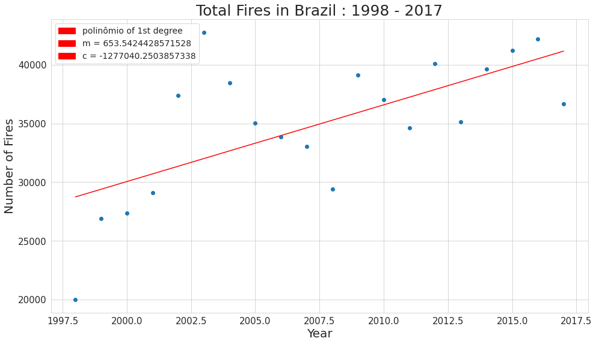

```python
#model

p = linear_regression(year_data['year'],year_data['number'])

#graphics style
plt.figure(figsize=(16,9))
plt.title('Total Fires in Brazil : 1998 - 2017', fontsize = 25)
plt.xlabel('Year', fontsize = 20)
plt.ylabel('Number of Fires', fontsize = 20)
plt.xticks(fontsize = 15)
plt.yticks(fontsize = 15)

#regression plot
x = np.array(year_data['year'])
y = np.zeros(year_data.shape[0])
for i in range(year_data.shape[0]):
    y[i] =  p[1] * x[i] + p[0]

#legends
grau = mpatches.Patch(color='red',label='polinômio of 1st degree')
m = mpatches.Patch(color='red',label='{} = {}'.format('m',p[1]))
c = mpatches.Patch(color='red',label='{} = {}'.format('c',p[0]))
plt.legend(loc='upper left',prop={'size':14},handles=[grau,m,c])

#plot
plt.plot(year_data['year'],year_data['number'],'o')
plt.plot(x,y,color='red')
plt.show()
```

# Polynomial regression

## -Parameters: as the equation is large, it is shown (rounded) above the graph for better visualization

- View the graph of the number of fires per month (sum of all years) to see the list.
- Performs the polynomial regression with different precision for visualization, since the month of September breaks the pattern and from there it is possible to compare how the regression with high precision shows one pattern and the one with less another. This analysis is interesting to analyze overfitting which can be a problem due to the presence of outliers.

```python
#visualize data

df = data.groupby(by='month').sum().reset_index()
df = df.drop('year',axis=1)
month_data = df

#loop that gets integer vale of month and puts in the new position
month = {'Janeiro':1,'Fevereiro':2,'Março':3,'Abril':4,'Maio':5,'Junho':6,'Julho':7,'Agosto':8,'Setembro':9,'Outubro':10,'Novembro':11,'Dezembro':12}
new_index = [None for i in range(12)]

for i in range(len(df['month'])):
    new_index[month[df['month'][i]]-1] = i

month_data = month_data.iloc[new_index].reset_index(drop='True')
month_data
```

|  | month | number |
| --- | --- | --- |
| 0 | Janeiro | 47747.844 |
| 1 | Fevereiro | 30848.050 |
| 2 | Março | 30717.405 |
| 3 | Abril | 28188.770 |
| 4 | Maio | 34731.363 |
| 5 | Junho | 56010.675 |
| 6 | Julho | 92326.113 |
| 7 | Agosto | 88050.435 |
| 8 | Setembro | 58578.305 |
| 9 | Outubro | 88681.579 |
| 10 | Novembro | 85508.054 |
| 11 | Dezembro | 57535.480 |

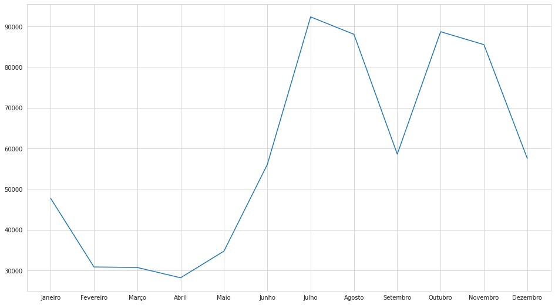

```python
#visualize graphic

plt.figure(figsize=(16,9))
plt.plot(month_data['month'],month_data['number'])
```

```
Equation: 49330.92 x0 + -30824.52 x1 + 11710.72 x2 + -1253.99 x3 + 47.04 x4 + 0 x5
```

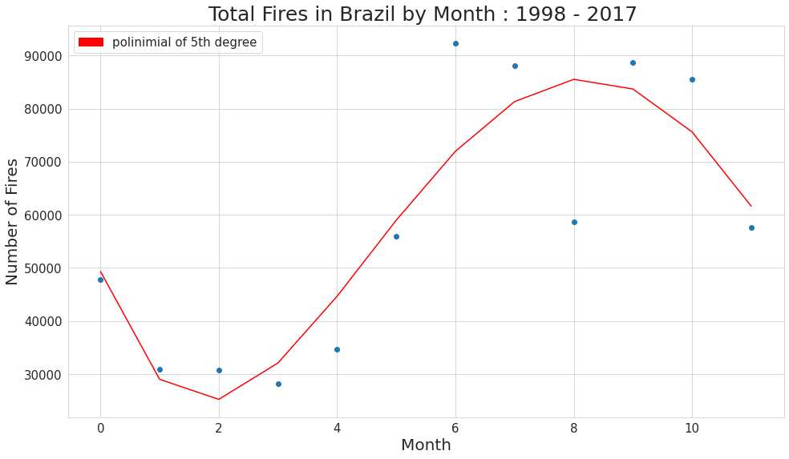

```python
#model with smaller precision

x = np.arange(12)
p = polynomial_regression(x,month_data['number'],5)
curve = np.poly1d(list(reversed(p)))
y = curve(x)


#graphics style
plt.figure(figsize=(16,9))
plt.title('Total Fires in Brazil by Month : 1998 - 2017 ', fontsize = 25)
plt.xlabel('Month', fontsize = 20)
plt.ylabel('Number of Fires', fontsize = 20)
plt.xticks(fontsize = 15)
plt.yticks(fontsize = 15)

#equation
equation = ''
for i in range(len(curve)):
    equation = ''.join([equation,str(round(curve[i],2)) + ' x' + str(i) + ' + '])
equation = ''.join([equation,str(round(curve[-1],2)) + ' x' + str(len(curve))])
print('Equation: ' + BOLD + equation + END)


#plot
grau = mpatches.Patch(color='red',label='polinimial of 5th degree')
plt.legend(loc='upper left',prop={'size':15},handles=[grau])
plt.plot(x,month_data['number'],'o')
plt.plot(x,y,color='red')
plt.show()
```

```
Equation: 47699.44 x0 + 139355.84 x1 + -402637.74 x2 + 394451.5 x3 + -192863.12 x4 + 53084.9 x5 + -8565.16 x6 + 802.01 x7 + -40.3 x8 + 0 x9
```

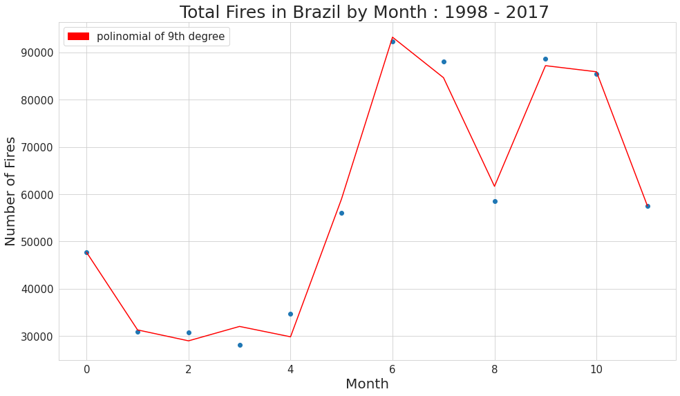

```python
#model with bigger precision

x = np.arange(12)
p = polynomial_regression(x,month_data['number'],9)
curve = np.poly1d(list(reversed(p)))
y = curve(x)


#graphics style
plt.figure(figsize=(16,9))
plt.title('Total Fires in Brazil by Month : 1998 - 2017 ', fontsize = 25)
plt.xlabel('Month', fontsize = 20)
plt.ylabel('Number of Fires', fontsize = 20)
plt.xticks(fontsize = 15)
plt.yticks(fontsize = 15)

#equation
equation = ''
for i in range(len(curve)):
    equation = ''.join([equation,str(round(curve[i],2)) + ' x' + str(i) + ' + '])
equation = ''.join([equation,str(round(curve[-1],2)) + ' x' + str(len(curve))])
print('Equation: ' + BOLD + equation + END)

#plot
grau = mpatches.Patch(color='red',label='polinomial of 9th degree')
plt.legend(loc='upper left',prop={'size':15},handles=[grau])
plt.plot(np.arange(12),month_data['number'],'o')
plt.plot(x,y,color='red')
plt.show()
```